# GEOG 5670 6670 Lab 00: Brief Introduction to Linux

Simon Brewer Geography Department University of Utah

30 January, 2022

## Objectives

In today’s class we will start using GRASS GIS from the command line. As this is running on a Linux server, we will first review some of the basics of working in a Unix system. This document is adapted from the introduction to linux from LSU HPC. The lab is designed to work on the CHPC OnDemand service, but will work equally well on a local installation of Linux, and most of the commands will work if you use a terminal under Mac OSX.

To start, open a new OnDemand session on the CHPC servers. To access the class OnDemand page, just enter the following address in your browser

https://ondemand-class.chpc.utah.edu/pun/sys/dashboard/batch_connect/sys/GEOG5670_desktop/

## Command-Line Interface

Like the family of UNIX *-like operating systems before it, the primary interface to Linux is the command-line. The command-line is still the most powerful and direct way to interact with the system. Shells are how command-line interfaces are implemented in Linux. Each shell has varying capabilities and features and the user should choose the shell that best suits their needs. The shell is simply an application running on top of the kernel and provides a powerful interface to the system.

### The *nix Shell

The shell is your workspace in the terminal. It is a command language interpreter that executes commands read from the standard input device or from a file.

| Shell Name | Developed by | Where | Remark |
| --- | --- | --- | --- |
| BSH (Bourne-Again SHell) | Brian Fox and Chet Ramey | Free Software Foundation | Most common shell in Linux |
| CSH (C SHell) | Bill Joy | University of California (For BSD) | The C shells syntax and usage are very similar to the C programming language |
| KSH (Korn SHell) | David Korn | AT & T Bell Labs |  |
| TCHS | See the man page |  | Enhanced version of CSH |

To find available shells in your system type:

```
cat /etc/shells
```

`cat` types out the contents of a file as you saw above. The file “shells” in the “/ etc” directory holds all available shells in the system.

To find your current shell type:

```
echo $SHELL
```

The command `echo` echos or types what follows it. The `$` sign says echo the cont ents of the following system variable. The `SHELL` is a system variable set up in your init file or by using the `export` command. Note that you can change the shell if you wish to use another one.

### Environment Variables

#### What are they?

> The shell’s environment is that umbrella of persistent knowledge under which the shell operates.

This information is stored as “environmental variables”, which are global variables that may be used at any point by the shell – either internally or when explicitly required by the user. Other variables can be customized by the user using a specific set of files contained in their HOME directory.

#### Why should I know about them?

Being able to know which environment variables affect which aspect of your environment means that you are able to customize your environment. In many shell scripts and using many applications or programming languages you will need to know the values of these variables. Your global environment consists of environment varibles such as:

`PATH` the variable that allows us to locate a command. Which gives all of the directories that the system should search through when looking for a specific command. To see what is in your path:

```
echo $PATH
```

`PWD` which holds the path of the working directory:

```
echo $PWD
```

`HOME` which holds the user’s home directory:

```
echo $HOME
```

`USER` holds the user name of the current account:

```
echo $USER
```

To see the overall value of your environment:

```
env | less
```

The `|` character is a ‘pipe’. This takes the output of one command and passes it to another. The Unix philosophy is to have a set of individual functions that only do one thing (“do one thing, and do it well”), so the pipe operator allows you to chain together multiple commands to create quite complex workflows from these individual pieces. Here, we use the `env` command to generate the list of environmental variables, and pipe it to `less`, a page program. This allows you to scroll up and down through the output, rather than it just all dunmping to the screen. You can also do some limited searching by typing `/` and then the string of characters you want to search for. Type `q` to quit.

### Filesystem Information

UNIX uses a true hierarchical filesystem, which is very different from the Windows structure. The UNIX filesystem starts at a single point: / (pronounced “root” [not to be confused with the root user or /root, the root user’s home directory]). Components

The UNIX filesystem is comprised of several parts:

- file: Files contain data, either for users or the system. The data can be text or binary.
- directory: A directory is a collection of files, like a folder in Windows.
- links: Links are pointers to existing files or directories, similar to shorcuts in Windows.
- special file: Special files include:
  - sockets
  - pipes
  - character
  - block
  - These special files are used by the kernel and running applications to control the flow of data in the system.

#### Everything is a file

One of the most difficult thing to grasp about the UNIX filesystem is that everything in UNIX is treated as a file. This includes directories, special files, partitions, disk drives, mice, serial ports, printers, displays, network interfaces, etc. Everything! Open the Terminal window and navigate to the /dev directory by typing:

```
cd /dev
```

Then list the files in this directory:

```
ls
```

Note that the list includes USB ports, CD/DVD-drives, etc.

#### Mounts (disk, NFS)

The UNIX filesystem is analogous to a tree. The root, `/`, is the root of the hypothetical tree and directories are the branches. The UNIX filesystem can have other filesystems attached onto them, and may be comprised of many different filesystems. The `mount` command is used to attach other file systems or to show existing attachments.

#### Common UNIX Directory Structure

The UNIX filesystem is traditionally divided into a number of common directories. The series of directories, separated by a slash (`/`) and often ending with a file, is called a path. Each directory path has a specific function. Below is a table listing some of the common directories and their normal use:

| Path | Windows equivalent | Description |
| --- | --- | --- |
| / | C: | The start or ‘root’ of the filesystem |
| /home | My Documents or Profiles | User’s private files |
| /usr or /usr/local | Program Files | Installed software |
| /dev | Windows or Windows System | Device drivers |
| /etc | The Registry or .ini files | Application and operating system configuration information |
| /tmp | Windows Temp | Temporary system files |
| /bin or /sbin | Windows | System executable files |

Note that you can usually see your current path in the terminal. To the left of the cursor is a string of characters:

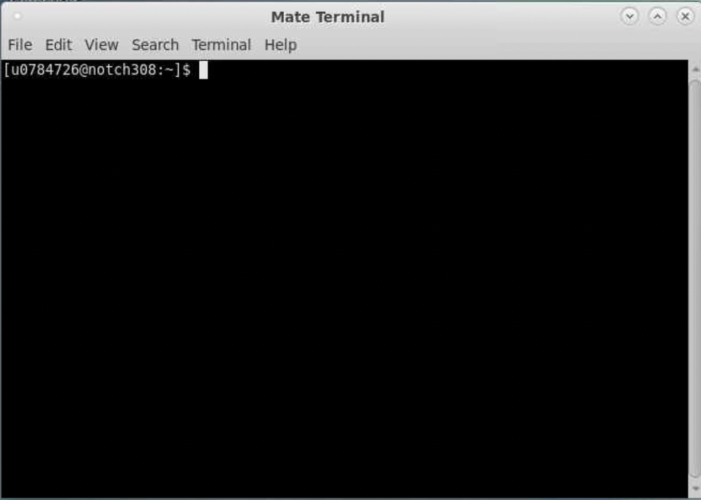

Terminal

The first part of this lists your user name and the name of the computer you are working on. To the right of the colon is the character `~`, which indicates that I am currently working in my home directory (`~` is shorthand for your home directory).

In the Terminal window, type

```
cd /
```

and press enter/return to “change directory” to the “root” directory.

This is the directory that all other directories spring from. Which, as in a tree is why it is called “root”. In the Terminal window, type

```
pwd
```

(don’t forget to press enter/return) to “print the working directory”.

Now type

```
cd
```

to change back to your account’s home directory, then type

```
pwd
```

to “print the working directory”. Note that an equivalent to `cd` is `cd ~`. The tilde character is used for a couple of reasons. First, the path to your home directory may be different on different systems (it’s more complex on the CHPC servers than a local installation for example). Second, if you want to use a more complex path, you can use this as a shorthand for all the file structure leading up to your home directory in an absolute path.

Unix distinguishes between absolute vs. relative paths. A relative path is simply given from the point you are working in at the moment. So if I was currently in my home directory, I can change to that directory with:

```
cd Documents
```

However, if I’m in a different folder, I would need to use an absolute path, which gives the full set of directories *above* the directory I want to change to

```
cd /uufs/chpc.utah.edu/common/home/u0784726/Documents
```

To avoid typing all of this, we can use the `~` character is a shortcut for the home directory:

```
cd ~/Documents
```

There are two other shortcuts that you might see used:

- `.`: is a shortcut to the current directory
- `..`: is a shortcut to the directory one level above where you are currently working.

For example, if I working in a folder with the full path of

```
/home/simon/Documents/geog5670/mydata/lab01/
```

Then `cd ..` would move to `/home/simon/Documents/geog5670/mydata/` and `cd ../..` would move to `/home/simon/Documents/geog5670/`, etc.

Now return to your home directory and list the files there:

```
cd
ls
```

Most Unix commands take arguments that change the way they work (for example the directory path that you want to change to is an argument for `cd`). To list all hidden files, try typing

```
ls -a
```

To show more information about the files

```
ls -l
```

Note that you can combine this to show detail of hidden files:

```
ls -al
```

Try `ls -lh` - what does this change?

### Command-line Primer

The following are some of the more frequently used filesystem commands:

| Command | Description | DOS/Windows Equivalent |
| --- | --- | --- |
| awk | File processing and report generating | N/A |
| cat | Show contents of a file | type or double-clicking a file |
| cd | Change directory | cd or double-clicking a folder |
| cp | Copy a file | copy or dragging a file |
| file | Determine file type | file extension or right-click properties |
| find | Find a file | Windows Explorer Find |
| grep | Find lines in a file | N/A |
| gzip | File compresser | WinZip/7Zip |
| less | Display a file one page at a time (extended version of more) | more |
| ln | Link a file to another file | Create Shortcut |
| ls | Display files in a directory | dir or Windows Explorer |
| mkdir | Create a directory | mkdir or creating a folder |
| more | Display a file one page at a time | more |
| mv | Move or rename a file | rename or dragging a file |
| rm | Remove a file | delete or deleting a file |
| rmdir | Remove a (empty) directory | rmdir or deleting a folder |
| sed | Stream editor | N/A |
| tar | Archive creator | N/A |
| unzip | File compresser | WinZip/7Zip |
| vim | Edit a file | edit or notepad |
| wc | Count words, lines and characters in a file | N/A |

## Working with files

For the next section, we’ll go through some examples of manipulating files in Linux. To start, go back to your home directory, then to your `Documents` folder:

```
cd ~/Documents
```

If you haven’t already done, create a `geog5670` folder here:

```
mkdir geog5670
cd geog5670
```

Now create a new folder to store the data and examples for this lab.

```
mkdir intro_linux
cd intro_linux
```

Next, you will need the file *example_data.tgz* file from Canvas. Download this file, and copy it to this folder (`intro_linx`) using the CHPC file manager. Go to your OnDemand dashboard page, then to the ‘Files’ dropdown menu and click on ‘Home directory’. In the new window, navigate to the folder you just created and drag and drop the file.

Go back to your desktop, and check the file is there (and its size):

[output not shown]

The file is a gzipped archive file (these will have the extension *.tgz* or *.tar.gz*). These are a little different from zipped files, in that there are two programs that create them. The first (`tar`) creates an archive of files and folders, and the second (`gzip`) compresses these. You can reverse this by unzipping the files with `gunzip` and then extracting all the files with `tar`, but more easily, you can run everything together with the following command:

```
tar zxvf example_data.tgz
```

The arguments `zxvf` do the following

- `z`: unzip the file
- `x`: extract the archive
- `v`: Use verbose model (i.e. print out what is going on)
- `f`: use the follwoing file name (as opposed to some input stream)

Note that if you replace the `x` with `t`, the program will list the contents, but not extract the files, which can be useful when searching. If you now list the contents of your folder (`ls`), you will see a new folder. Change to this now

```
cd example_data
ls -al
```

You should see a set of files. Now look at the contents of a file:

```
cat lc96metadata.txt
```

In the Terminal window type

```
cp lc96metadata.txt myfile1.txt
```

to copy the version file you just looked at, making a second identical file with a new name, “myfile1.txt”.

In the Terminal window type the following to determine the file type:

```
file myfile1.txt
```

To create a new directory called “mydir” type:

```
mkdir mydir1
```

To copy the file you just made into `mydir1`:

```
cp myfile1.txt mydir1/
```

```
cp myfile1.txt mydir1/myfile2.txt
```

To copy all the files with a *.txt extension

```
cp *.txt mydir1/
```

To list all the files in the new directory “mydir” type:

```
ls -l mydir1
```

If you want to copy an entire directory with all its contents (the `-r` makes a recursive copy)

```
cp -r mydir1/ mydir2/
```

To find the number of newlines, words and bytes in a file type:

```
wc myfile1.txt
```

And you can just list the number of lines with (`wc -l myfile1.txt`)

To rename a file type:

```
mv myfile1.txt myfile2.txt
```

And to remove a file type:

```
rm myfile2.txt
```

If you try to remove an entire directory, you will get an error:

```
cd ..
rm mydir2/
```

> rm: cannot remove mydir2/: Is a directory

To delete this, you need two arguments (`r` for recursive deletion and `f` to force the operation). **Be careful with this as there is no ’trash bin`, and you can’t undo it!**

```
rm -rf mydir2
```

Note that most of these commands will work with wildcards (`*`). Change to the `mydir1` folder:

```
cd mydir1
ls *.txt
wc -l *.txt
```

And you can use wildcards to select using parts of file names. If we only want to look at the files starting with `lc96`:

```
ls lc96*.txt
wc -l lc96*.txt
```

## Users, Groups and Permissions

In Linux a user is identified by their username. Linux usernames are similar to Windows logon IDs. Linux maintains a list of users, called a name space, either locally on each individual machine or across the network via NIS for a group of machines.

User == uid

Each user on a Linux machine has a unique username that corresponds to a unique uid. The uid is a numeric value used to determine if the user is authorized to perform a particular task. It is important to note that the Linux operating system is concerned only with the numeric value of the uid and not the text that describes the user’s name.

Group == gid

Groups are also associated with unique numbers called gids. Users may belong to more than one group, although they can be associated with only one group at a time. Groups may have zero, one, or more members. Like uids, the Linux operating system is concerned only with the numeric value of the gid and not the textual name of the group.

#### Authentication

Each time a user tries to login, Linux attempts to authenticate that user against a name space. The login process prompts for a username and, usually, a password. Linux then encrypts the entered password and checks to see if the encrypted text matches the stored version of the user’s encrypted password. If there is a match, the user is authenticated; if not, the user is denied access.

### Permissions

Since Linux treats everything as a file, learning about file permissions is very important. Linux allows access to a file based upon affiliation as defined by user, group, and other. The possible permissions for each affiliation are read (r), write (w), and execute (x). Linux actually uses one bit to indicate these three permissions for each of the three affiliations.

In the Terminal window, type

```
ls -l /etc/passwd
```

Your output should look similar to this:

> -rw-r–r– 1 root root 4005 Apr 23 2019 /etc/passwd

The first dash is a flag specifying the type of file. The next three characters are the permissions for the user who owns the file. The next three characters are the permissions for the group associated with the file. The final three characters are the permissions for any user who is not the owner of the file nor belongs to the group associated with the file.

Each of the permissions has a different meaning depending on whether it is set for a file or a directory:

| Type | r | w | x |
| --- | --- | --- | --- |
| File | Can read the file | Can change the contents or delete the file | Can execute the file |
| Directory | Can see a listing of files in the directory | Can create new files in the directory or delete files from the directory | Can change into that directory |

In the case of the /etc/passwd file, only the account ‘root’ (the superuser) can write to the file, but everyone can read it. As we’ll see in the next section, these permissions can be changed, but only if you are the owner of the file.

## Beginning Shell Scripting

We will now try some examples of shell scripting using the BASH shell. This is the easiest way to automate tasks in Unix, including analyses in GRASS. You will need a text editor to write the scripts, and there are several that can be used, including:

- Vi/Vim
- Emacs
- ed

There will be several under the ‘Applications’ > ‘Accessories’ menu on the CHPC desktop, but here, we will use vim, a standard text editor that can be used through the terminal. First, make sure you are in your `intro_linx` folder.

```
cd ~/Documents/geog5670/intro_linux
```

To start vim with a new script, type:

```
vim myscript.sh
```

A window will open that looks like this:

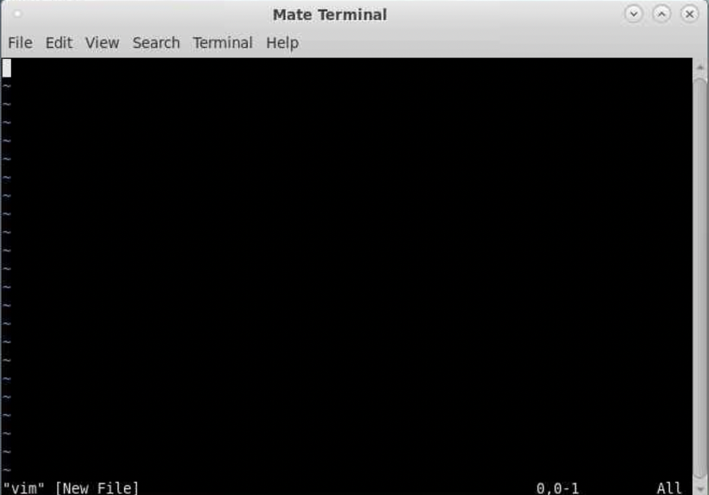

Vim

More detail on the vim editor is given below, but for now, press `i` to enter text insertion mode, then type the following:

```
#!/bin/bash
clear
echo "Hello World - this is my first shell script"
```

The first line sets the interpreter to use for the following commands. As we are running this in Bash, we don’t really need this here, but it’s usually safer to add it. Note that this is not restricted to the shell interpreters, but you can use most interpreted languages (e.g. Python).

Now hit the `ESC` button to leave text insertion mode, and type `:wq` to save your input and quit the editor. After writing your scripts you need to change the permissions, so the execute permission is on for the user, then the script can be run from the command line by prefacing it with `./`:

```
chmod u+x myscript
./myscript.sh
```

Lets create another script to print user information, who is currently logged in , current date & time:

```
vim ginfo.sh
```

Enter the following text:

```
#!/bin/bash
clear
echo "Hello $USER"
echo -n "Today is "; date
echo -n "Number of user login: " ; who | wc -l
echo "Calendar"
cal
exit 0
```

Now, exit the file as before (`ESC` then `:wq`), set the permissions, then execute the script.

## Viewing Files

One of the things that are very important is to see some of the information in a given file. Make sure you are in the ‘example_data’ directory, and we will look at the file schools_landuse.txt. Commands to do this include:

`cat` - shows you the contents of an entire file (you will see only the last screen full of lines).

```
cd example_data
cat schools_landuse.txt
```

`less` - shows you the contents of an entire file one screen at a time:

```
less schools_landuse.txt
```

- to go to the next screen hit the space bar
- to see only the next line hit the Return key
- to quit more hit the “q” key

`head` - shows you the first 10 lines of a file

```
head schools_landuse.txt
```

to see fewer or more lines us the -n option

```
head -3 schools_landuse.txt
```

`tail` - shows you the last 10 lines of a file

```
tail schools_landuse.txt
tail -3 schools_landuse.txt
```

## Redirection and I/O

Most command line programs will take some form of input, and give some form of output. By default, this is either taken from STDIN and written to STDOUT (i.e. the terminal). Redirection allows you to use files instead for this, using the `>` and `<` symbols. For example, the following takes the output of the `ls` function for the current directory and writes it to a file

```
ls . > filelist.txt
head filelist.txt
```

Note that you can also redirect the other way, so to print out the file we just made:

```
cat < filelist.txt
```

The other part of redirection uses pipes to pass output from one program to a second. Using pipes is extremely useful in Linux, as it allows you to combine several simple command line programs to make a fairly complex set of file and data manipulation. A pipe between two programs is given by the `|` symbol. For example, this lists the files in the directory, then passes this list through the `sort` function with a `-r` parameter to do a reverse sort:

```
ls | sort -r
```

Here the pipe has the line count command (`wc`) read its input from the `ls` command’s output. The result is the number of lines of output, which is the number of files in the directory.

```
ls | wc -l
```

And here we pipe the output of `ls` through `grep` to select only the lines with the character string ‘li’ in them

```
ls | grep li
```

## Learning vi/vim

Vi and vim are text editors (vim is an ‘improved’ version of vi). Vi comes on every UNIX-like system by default, and vim is usually available. While there are many other text editors, and different people believe different ones are the best, we will look at vi/vim here as it can always be found on a UNIX-like OS, unless the system administrator has removed it (not likely). We will concentrate on vim as it is a little easier to use, but the basic commands can be used in vi, if this is all that is available.

Vi/vim has two modes:

- command mode - allows you to use the normal keys to give movement and text editing commands, copying and pasting, etc
- text mode - allows you to use the normal keys to enter text into your file

To create a file, choose a name that doesn’t exist in the directory, e.g. `vim newfile`. This creates the new file, opens it and puts you in command mode. Lets create a new file, a list of files for the North Carolina dataset.

```
ls > filelist.txt
vim filelist.txt
```

The file opens in command mode. If the file doesn’t exist then you will see a screen with tildes “~”. If the file does exist you will see the first page of text in the file.

In order to add, delete or change text, we need to change to text mode. In order to enter text mode, you need to use one of the following commands:

- `i` - insert new text to the left of the character the cursor is on
- `I` - insert new text to the left of the first non-blank character on the line
- `a` - insert new text to the right of the character the cursor is on
- `A` - insert new text to the right of the last character on the line
- `o` - inserts a new line below the line the cursor is on
- `O` - inserts a new line above the line the cursor is on

Now that we know the basic commands, we can make some changes to this file:

- Go to the start of the first line
- hit the `O` key to insert a line above the existing text
- Enter some text here to describe the file.
- hit the escape key
- Type `:wq`

Typing `:wq` saves and closes the file. The `:` tells vi that a command is coming up next, the `w` tells vi to write the file to disk (save the file) and the `q` tells vi to quit. If you don’t type the `q` vi saves the file and lets you continue. If you have made changes that you don’t want to keep, then typing `:q!` will quit without saving.

**UNDO if you want to undo any operation in vim, just hit the `u` key while in command mode.**

#### Copying and pasting

The three main commands for copying and pasting are:

- `d` - cut text
- `y` - copy text
- `p` - paste text

Reopen the file you have been using in vim, and try the following

- Go to the first character of any line, and while in command mode, press `d`. Nothing will happen until you press the direction key. Up or down will cut the line above or below the cursor, and left or right will cut the first character in that direction. Press right to cut the character under the cursor
- Now move to the end of the line and press `p` to paste the text to the right of where the cursor is. Pressing Shift-`p` will paste to the left
- Now repeat this, but instead of pressing `d` in the first step, press `y` to copy
- If you use these commands after having entered a number, then you will cut or copy that number of characters. Go to the start of any line and press `5y`, then go to the end and press `p`. The first five characters will be copied and pasted
- To move an entire line, the easiest way is to put the cursor on the line, and press `dd`. The line will be cut, then move to where you want the line and press `p` to paste. As before, entering a number before the `dd` will cut multiple lines.

#### Find and replace

Vi/vim has a quite sophisticated (and pretty complex) find and replace method. To find anything in the file, simply use `/` while in command mode. For example `/a` will find all the ’a’s in the file. Press `n` to move to the next one.

There is much more that can be done, including the use of regular expressions. A good site for examples and tutorials is the [vim site](http://www.vim.org/).

### Getting Help from the System

- Man pages give the syntax of a command in UNIX like operating systems. These are manuals which give you information on the commands: syntax, options, etc. To access these pages for a command type `man command-name`. Type:

```
man cp
```

This gives the information on the cp (copy) command. Press ‘q’ to quit.

Open source software is generally tightly linked to the development of the internet, and the greatest source of help, tutorials and examples can be found there. Particularly recommended are

- [Stack exchange](http://stackexchange.com)
- [The Linux Documentation Project](http://www.tldp.org/)
- [The O’Reilly series of books](http://www.oreilly.com/)

## Logging off

When you’re finished, don’t forget to log off from the CHPC server by going to the menu on the left of the screen and selecting the ‘Disconnect’ icon at the bottom.